# Infrastructure Investment and Jobs Act Exploration using GGPlot2 Library in R

Mohamed Hassan-El Serafi

2023-09-10

```r
library(tidyverse)
library(stringr)
library(reactable)
```

## Key Questions That Will Be Explored In This Analysis:

- Is the allocation equitable based on the population of each of the States and Territories, or is bias apparent?
- Does the allocation favor the political interests of the Biden administration?

### Infrastructure Investment & Jobs Act Funding Dataset

```r
df <- read.csv("https://raw.githubusercontent.com/moham6839/DATA_608_Assignment1/main/IIJA%20FUNDING%20AS%20OF%20MARCH%202023(1).csv", check.names = FALSE)
```

```r
reactable(df)
```

| State, Teritory or Tribal Nation | Total (Billions) |
| --- | --- |
| ALABAMA | 3 |
| ALASKA | 3.7 |
| AMERICAN SAMOA | 0.0686 |
| ARIZONA | 3.5 |
| ARKANSAS | 2.8 |
| CALIFORNIA | 18.4 |
| COLORADO | 3.2 |
| CONNECTICUT | 2.5 |
| DELEWARE | 0.792 |
| DISTRICT OF COLUMBIA | 1.1 |

[output cut: 47 more lines]

```r
df <- rename(df, `state` = `State, Teritory or Tribal Nation`, `Total_Billions` = `Total (Billions)`)
```

```r
df <- df %>%
  mutate(state = replace(state, state == "DELEWARE", "DELAWARE"))
```

```r
reactable(df)
```

| state | Total_Billions |
| --- | --- |
| ALABAMA | 3 |
| ALASKA | 3.7 |
| AMERICAN SAMOA | 0.0686 |
| ARIZONA | 3.5 |
| ARKANSAS | 2.8 |
| CALIFORNIA | 18.4 |
| COLORADO | 3.2 |
| CONNECTICUT | 2.5 |
| DELAWARE | 0.792 |
| DISTRICT OF COLUMBIA | 1.1 |

[output cut: 47 more lines]

I changed the values of the Total Billions column to reflect the actual values of the funding:

```r
df$Total_Billions <- df$Total_Billions*1e9
```

## Is the allocation equitable based on the population of each of the States and Territories, or is bias apparent?

### Current Population of U.S. States and Territories

```r
df4 <- read.csv("https://raw.githubusercontent.com/moham6839/DATA_608_Assignment1/main/U.S.%20State%20Population%20Data.csv", check.names = FALSE, header=FALSE)
```

```r
reactable(df4)
```

| V1 | V2 | V3 | V4 | V5 |
| --- | --- | --- | --- | --- |
| table with row headers in column A and column headers in rows 3 through 4. (leading dots indicate sub-parts) |  |  |  |  |
| Annual Estimates of the Resident Population for the United States, Regions, States, District of Columbia, and Puerto Rico: April 1, 2020 to July 1, 2022 |  |  |  |  |
| Geographic Area | April 1, 2020 Estimates Base | Population Estimate (as of July 1) |  |  |
|  |  | 2020 | 2021 | 2022 |
| United States | 331,449,520 | 331,511,512 | 332,031,554 | 333,287,557 |
| Northeast | 57,609,156 | 57,448,898 | 57,259,257 | 57,040,406 |
| Midwest | 68,985,537 | 68,961,043 | 68,836,505 | 68,787,595 |
| South | 126,266,262 | 126,450,613 | 127,346,029 | 128,716,192 |
| West | 78,588,565 | 78,650,958 | 78,589,763 | 78,743,364 |
| .Alabama | 5,024,356 | 5,031,362 | 5,049,846 | 5,074,296 |

[output cut: 57 more lines]

```r
new_df4 <- df4 %>%
  select(1, 5)
```

```r
reactable(new_df4)
```

| V1 | V5 |
| --- | --- |
| table with row headers in column A and column headers in rows 3 through 4. (leading dots indicate sub-parts) |  |
| Annual Estimates of the Resident Population for the United States, Regions, States, District of Columbia, and Puerto Rico: April 1, 2020 to July 1, 2022 |  |
| Geographic Area |  |
|  | 2022 |
| United States | 333,287,557 |
| Northeast | 57,040,406 |
| Midwest | 68,787,595 |
| South | 128,716,192 |
| West | 78,743,364 |
| .Alabama | 5,074,296 |

[output cut: 57 more lines]

```r
new_df5 <- new_df4 %>%
  filter(!row_number() %in% c(1, 2, 3, 4,5, 6, 7, 8, 9, 63, 64, 65, 66))
reactable(new_df5)
```

| V1 | V5 |
| --- | --- |
| .Alabama | 5,074,296 |
| .Alaska | 733,583 |
| .Arizona | 7,359,197 |
| .Arkansas | 3,045,637 |
| .California | 39,029,342 |
| .Colorado | 5,839,926 |
| .Connecticut | 3,626,205 |
| .Delaware | 1,018,396 |
| .District of Columbia | 671,803 |
| .Florida | 22,244,823 |

[output cut: 44 more lines]

```r
df6 <- new_df5 %>%
  filter(!row_number() %in% c(54))
reactable(df6)
```

| V1 | V5 |
| --- | --- |
| .Alabama | 5,074,296 |
| .Alaska | 733,583 |
| .Arizona | 7,359,197 |
| .Arkansas | 3,045,637 |
| .California | 39,029,342 |
| .Colorado | 5,839,926 |
| .Connecticut | 3,626,205 |
| .Delaware | 1,018,396 |
| .District of Columbia | 671,803 |
| .Florida | 22,244,823 |

[output cut: 43 more lines]

```r
df6$V1 <- sub("^.", "", df6$V1)
```

```r
reactable(df6)
```

| V1 | V5 |
| --- | --- |
| Alabama | 5,074,296 |
| Alaska | 733,583 |
| Arizona | 7,359,197 |
| Arkansas | 3,045,637 |
| California | 39,029,342 |
| Colorado | 5,839,926 |
| Connecticut | 3,626,205 |
| Delaware | 1,018,396 |
| District of Columbia | 671,803 |
| Florida | 22,244,823 |

[output cut: 43 more lines]

```r
df7 <- rename(df6, state = V1, Population_Estimate_2022 = V5)
```

```r
df7$Population_Estimate_2022 <- gsub(",", "", df7$Population_Estimate_2022)
```

```r
reactable(df7)
```

| state | Population_Estimate_2022 |
| --- | --- |
| Alabama | 5074296 |
| Alaska | 733583 |
| Arizona | 7359197 |
| Arkansas | 3045637 |
| California | 39029342 |
| Colorado | 5839926 |
| Connecticut | 3626205 |
| Delaware | 1018396 |
| District of Columbia | 671803 |
| Florida | 22244823 |

[output cut: 43 more lines]

```r
df7 <- df7 %>%
  mutate(across(where(is.character), toupper))
```

```r
new_country_pop <- data.frame(c("AMERICAN SAMOA", "GUAM", "US VIRGIN ISLANDS",
                                "NORTHERN MARIANA ISLANDS", "TRIBAL COMMUNITIES"),
                              c(44620, 169330, 104917, 51295, 9700000))
names(new_country_pop) <- c("state", "Population_Estimate_2022")

combined_df <- rbind(df7, new_country_pop)
```

```r
reactable(combined_df)
```

| state | Population_Estimate_2022 |
| --- | --- |
| ALABAMA | 5074296 |
| ALASKA | 733583 |
| ARIZONA | 7359197 |
| ARKANSAS | 3045637 |
| CALIFORNIA | 39029342 |
| COLORADO | 5839926 |
| CONNECTICUT | 3626205 |
| DELAWARE | 1018396 |
| DISTRICT OF COLUMBIA | 671803 |
| FLORIDA | 22244823 |

[output cut: 48 more lines]

```r
combined_df$Population_Estimate_2022 = as.numeric(as.character(combined_df$Population_Estimate_2022))
```

```r
final_df <- inner_join(df, combined_df, by="state")
```

```r
reactable(final_df)
```

| state | Total_Billions | Population_Estimate_2022 |
| --- | --- | --- |
| ALABAMA | 3000000000 | 5074296 |
| ALASKA | 3700000000 | 733583 |
| AMERICAN SAMOA | 68600000 | 44620 |
| ARIZONA | 3500000000 | 7359197 |
| ARKANSAS | 2800000000 | 3045637 |
| CALIFORNIA | 18400000000 | 39029342 |
| COLORADO | 3200000000 | 5839926 |
| CONNECTICUT | 2500000000 | 3626205 |
| DELAWARE | 792000000 | 1018396 |
| DISTRICT OF COLUMBIA | 1100000000 | 671803 |

[output cut: 47 more lines]

## Creating Per Capita Column

In order to get a sense of the amount of funding in proportion to the population of each state/territory, I calculated the Per Capita allocation of funding to each person, dividing the amount of money by the state/territory population:

```r
final_df2 <- final_df %>%
  mutate(Per_Capita = round((Total_Billions)/(Population_Estimate_2022), 2))
reactable(final_df2)
```

| state | Total_Billions | Population_Estimate_2022 | Per_Capita |
| --- | --- | --- | --- |
| ALABAMA | 3000000000 | 5074296 | 591.22 |
| ALASKA | 3700000000 | 733583 | 5043.74 |
| AMERICAN SAMOA | 68600000 | 44620 | 1537.43 |
| ARIZONA | 3500000000 | 7359197 | 475.6 |
| ARKANSAS | 2800000000 | 3045637 | 919.35 |
| CALIFORNIA | 18400000000 | 39029342 | 471.44 |
| COLORADO | 3200000000 | 5839926 | 547.95 |
| CONNECTICUT | 2500000000 | 3626205 | 689.43 |
| DELAWARE | 792000000 | 1018396 | 777.69 |
| DISTRICT OF COLUMBIA | 1100000000 | 671803 | 1637.38 |

[output cut: 47 more lines]

### Plot of Population and Per Capita Distribution of Jobs Act Funding

Using population data from the Census and CIA, I compared each state and territory’s current population:

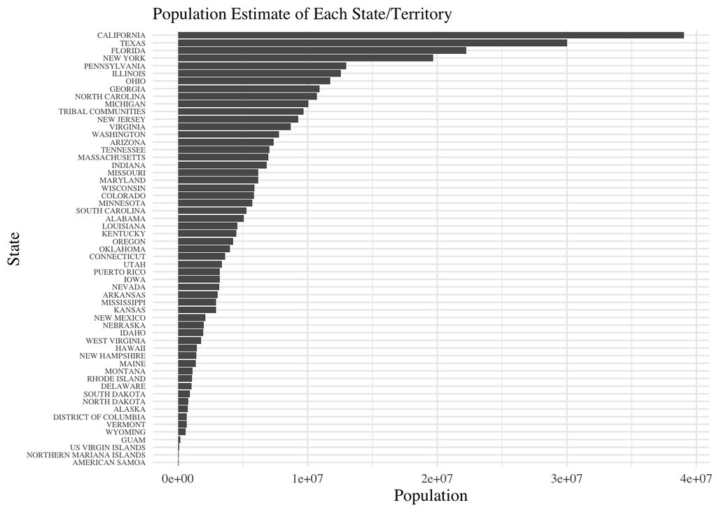

```r
final_df2 %>%
  ggplot(mapping = aes(x=reorder(`state`, Population_Estimate_2022), y=`Population_Estimate_2022`)) +
  geom_bar(stat = "identity", position = "dodge") +
  coord_flip() +
  theme_minimal() +
  theme(plot.title=element_text(size=12, family="serif"),
        axis.title = element_text(size=12, family="serif"),
        axis.text.x = element_text(size=9, family="serif"),
        text = element_text(size=7, family="serif")) +
  labs(title = "Population Estimate of Each State/Territory",
       y="Population",
       x="State")
```

The five states/territories with the highest population are California, Texas, Florida, New York, and Pennsylvania. The five states/territories with the lowest population are American Samoa, Northern Mariana Islands, US Virgin Islands, Guam, and Wyoming.

## Per Capita

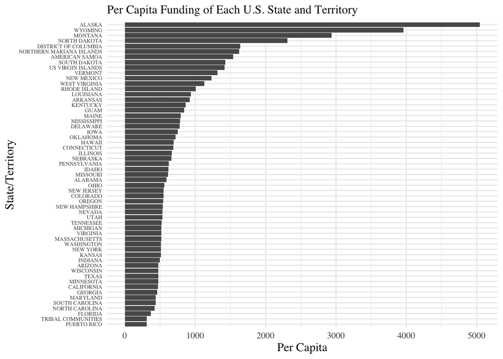

```r
final_df2 %>%
  ggplot(mapping = aes(x=reorder(`state`, Per_Capita), y=`Per_Capita`)) +
  geom_bar(stat = "identity", position = "dodge") +
  coord_flip() +
  theme_minimal() +
  theme(plot.title=element_text(size=12, family="serif"),
        axis.title = element_text(size=12, family="serif"),
        axis.text.x = element_text(size=9, family="serif"),
        text = element_text(size=7, family="serif")) +
  labs(title = "Per Capita Funding of Each U.S. State and Territory",
       y="Per Capita",
       x="State/Territory")
```

## Does the allocation favor the political interests of the Biden administration?

### 2020 Presidential Election Dataset

The U.S. territories (Puerto Rico, American Samoa, Guam, Northern Mariana Islands, Virgin Islands) are not allowed to vote in Presidential elections, and therefore will not be included in the analysis of comparing funding to the 2020 Presidential election results. Additionally, voting data from tribal communities were unavailable, and will also not be included in this specific analysis.

```r
df2 <- read.csv("https://raw.githubusercontent.com/moham6839/DATA_608_Assignment1/main/1976-2020-president.csv", check.names = FALSE)
```

```r
df3 <- df2 %>%
  select(year, state, candidate, party_detailed, candidatevotes, totalvotes) %>%
  filter(year == 2020) %>%
  filter(party_detailed == "DEMOCRAT" | party_detailed == "REPUBLICAN")
```

```r
reactable(df3)
```

| year | state | candidate | party_detailed | candidatevotes | totalvotes |
| --- | --- | --- | --- | --- | --- |
| 2020 | ALABAMA | BIDEN, JOSEPH R. JR | DEMOCRAT | 849624 | 2323282 |
| 2020 | ALABAMA | TRUMP, DONALD J. | REPUBLICAN | 1441170 | 2323282 |
| 2020 | ALASKA | BIDEN, JOSEPH R. JR | DEMOCRAT | 153778 | 359530 |
| 2020 | ALASKA | TRUMP, DONALD J. | REPUBLICAN | 189951 | 359530 |
| 2020 | ARIZONA | BIDEN, JOSEPH R. JR | DEMOCRAT | 1672143 | 3387326 |
| 2020 | ARIZONA | TRUMP, DONALD J. | REPUBLICAN | 1661686 | 3387326 |
| 2020 | ARKANSAS | BIDEN, JOSEPH R. JR | DEMOCRAT | 423932 | 1219069 |
| 2020 | ARKANSAS | TRUMP, DONALD J. | REPUBLICAN | 760647 | 1219069 |
| 2020 | CALIFORNIA | BIDEN, JOSEPH R. JR | DEMOCRAT | 11110250 | 17500881 |
| 2020 | CALIFORNIA | TRUMP, DONALD J. | REPUBLICAN | 6006429 | 17500881 |

[output cut: 92 more lines]

```r
pres_funding_df <- inner_join(df, df3, by="state")
```

```r
reactable(pres_funding_df)
```

| state | Total_Billions | year | candidate | party_detailed | candidatevotes | totalvotes |
| --- | --- | --- | --- | --- | --- | --- |
| ALABAMA | 3000000000 | 2020 | BIDEN, JOSEPH R. JR | DEMOCRAT | 849624 | 2323282 |
| ALABAMA | 3000000000 | 2020 | TRUMP, DONALD J. | REPUBLICAN | 1441170 | 2323282 |
| ALASKA | 3700000000 | 2020 | BIDEN, JOSEPH R. JR | DEMOCRAT | 153778 | 359530 |
| ALASKA | 3700000000 | 2020 | TRUMP, DONALD J. | REPUBLICAN | 189951 | 359530 |
| ARIZONA | 3500000000 | 2020 | BIDEN, JOSEPH R. JR | DEMOCRAT | 1672143 | 3387326 |
| ARIZONA | 3500000000 | 2020 | TRUMP, DONALD J. | REPUBLICAN | 1661686 | 3387326 |
| ARKANSAS | 2800000000 | 2020 | BIDEN, JOSEPH R. JR | DEMOCRAT | 423932 | 1219069 |
| ARKANSAS | 2800000000 | 2020 | TRUMP, DONALD J. | REPUBLICAN | 760647 | 1219069 |
| CALIFORNIA | 18400000000 | 2020 | BIDEN, JOSEPH R. JR | DEMOCRAT | 11110250 | 17500881 |
| CALIFORNIA | 18400000000 | 2020 | TRUMP, DONALD J. | REPUBLICAN | 6006429 | 17500881 |

[output cut: 92 more lines]

```r
pres_funding_df2 <- pres_funding_df %>%
  mutate(Vote_Results_Pct = round((candidatevotes/totalvotes)*100, 2)) %>%
  group_by(state) %>%
  mutate(Party_Winner = party_detailed[which.max(Vote_Results_Pct)])
```

```r
reactable(pres_funding_df2)
```

| state | Total_Billions | year | candidate | party_detailed | candidatevotes | totalvotes | Vote_Results_Pct | Party_Winner |
| --- | --- | --- | --- | --- | --- | --- | --- | --- |
| ALABAMA | 3000000000 | 2020 | BIDEN, JOSEPH R. JR | DEMOCRAT | 849624 | 2323282 | 36.57 | REPUBLICAN |
| ALABAMA | 3000000000 | 2020 | TRUMP, DONALD J. | REPUBLICAN | 1441170 | 2323282 | 62.03 | REPUBLICAN |
| ALASKA | 3700000000 | 2020 | BIDEN, JOSEPH R. JR | DEMOCRAT | 153778 | 359530 | 42.77 | REPUBLICAN |
| ALASKA | 3700000000 | 2020 | TRUMP, DONALD J. | REPUBLICAN | 189951 | 359530 | 52.83 | REPUBLICAN |
| ARIZONA | 3500000000 | 2020 | BIDEN, JOSEPH R. JR | DEMOCRAT | 1672143 | 3387326 | 49.36 | DEMOCRAT |
| ARIZONA | 3500000000 | 2020 | TRUMP, DONALD J. | REPUBLICAN | 1661686 | 3387326 | 49.06 | DEMOCRAT |
| ARKANSAS | 2800000000 | 2020 | BIDEN, JOSEPH R. JR | DEMOCRAT | 423932 | 1219069 | 34.78 | REPUBLICAN |
| ARKANSAS | 2800000000 | 2020 | TRUMP, DONALD J. | REPUBLICAN | 760647 | 1219069 | 62.4 | REPUBLICAN |
| CALIFORNIA | 18400000000 | 2020 | BIDEN, JOSEPH R. JR | DEMOCRAT | 11110250 | 17500881 | 63.48 | DEMOCRAT |
| CALIFORNIA | 18400000000 | 2020 | TRUMP, DONALD J. | REPUBLICAN | 6006429 | 17500881 | 34.32 | DEMOCRAT |

[output cut: 92 more lines]